# Problem Set 1

## 10. Replicate Figure 2b from the paper. I recommend using the package `ggplot2`.

You’ll need to check the Appendix to get the exact group of schools. Interpret the graph. Save it to your output folder.

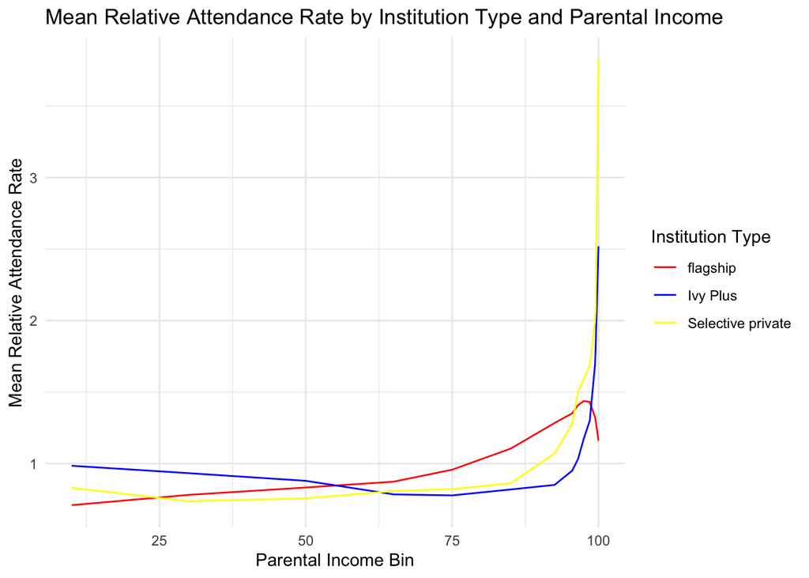

```r
## Sourcing first
source('/Users/samuelcrawford/Desktop/Big Data/big-data-PS1MaggieSam2nd/housekeeping.r')

# Load necessary libraries
library(ggplot2)
library(readr)  # for read_csv
library(dplyr)  # for data manipulation

# Reading the data
file_path <- "../data/CollegeAdmissions.csv"  # Adjust this if your file path is different
data <- read_csv(file_path)
# Prepare the data for "flagship"
flagship_data <- data %>%
  filter(flagship == 1) %>%
  group_by(par_income_bin) %>%
  summarise(mean_rel_attend = mean(rel_attend, na.rm = TRUE))

# Prepare the data for "Ivy Plus" and "Other Selective Private" under "tier"
tier_data <- data %>%
  filter(tier %in% c("Ivy Plus", "Selective private")) %>%
  group_by(tier, par_income_bin) %>%
  summarise(mean_rel_attend = mean(rel_attend, na.rm = TRUE))
# Combine the data
combined_data <- bind_rows(
  flagship_data %>% mutate(tier = "flagship"),
  tier_data
)

# Plotting
ggplot(combined_data, aes(x = par_income_bin, y = mean_rel_attend, color = tier)) +
  geom_line() +
  scale_color_manual(values = c("flagship" = "red", "Ivy Plus" = "blue", "Selective private" = "yellow")) +
  labs(title = "Mean Relative Attendance Rate by Institution Type and Parental Income",
       x = "Parental Income Bin",
       y = "Mean Relative Attendance Rate",
       color = "Institution Type") +
  theme_minimal()
```

```r
# Saving the plot to the output folder
output_path <- "output/mean_relative_attendance_rate_plot.png"  # Adjust this if your output path is different
ggsave(output_path, width = 10, height = 8)
```

## 11. Replicate Figures 3a and 3b from the paper with 95% CI bars. Save them to your output folder. Interpret these graphs.

```r
ggplot(data=school_data)
```

## 11. Replicate Figures 4a and 4b from the paper with 95% CI bars. Save them to your output folder. Interpret these graphs.

```r
ggplot(data=school_data)
```

## 12a. Plot the relative application, attendance, and matriculation rates for the schools in the NESCAC. Save it to your output folder. Interpret this graph.

Ok, firstly I’m really struggling with that Matriculation rate and how that is different from attendance rate. I’ve included something that might be what you are looking for, but it can’t be used in relation to 12b.

```r
# Sourcing first

source('/Users/samuelcrawford/Desktop/Big Data/big-data-PS1MaggieSam2nd/housekeeping.r')
library(ggplot2)
library(readr)  # for read_csv
library(dplyr)  # for data manipulation

# Reading the data
file_path <- "../data/CollegeAdmissions.csv"  # Adjust this if your file path is different
data <- read_csv(file_path)
# Define the list of colleges
selected_colleges <- c("Amherst College", "Bates College", "Bowdoin College",
                       "Colby College", "Connecticut College", "Hamilton College",
                       "Middlebury College", "Trinity College", "Tufts University",
                       "Wesleyan College", "Williams College")

# Filter the data for the selected colleges
filtered_data <- data %>%
  filter(name %in% selected_colleges)

# Create a scatter plot with lines for rel_apply
plot_apply <- ggplot(filtered_data, aes(x = par_income_bin, y = rel_apply, color = name, group = name)) +
  geom_point() +
  geom_line() +
  theme_minimal() +
  theme(axis.text.x = element_text(angle = 45, hjust = 1)) +
  ggtitle("rel_apply by par_income_bin")

# Create a scatter plot with lines for rel_attend
plot_attend <- ggplot(filtered_data, aes(x = par_income_bin, y = rel_attend, color = name, group = name)) +
  geom_point() +
  geom_line() +
  theme_minimal() +
  theme(axis.text.x = element_text(angle = 45, hjust = 1)) +
  ggtitle("rel_attend by par_income_bin")
```

## 12b. Add 95% confidence intervals to the plot you just made.

```r
# Sourcing first
source('/Users/samuelcrawford/Desktop/Big Data/big-data-PS1MaggieSam2nd/housekeeping.r')

# Load necessary libraries
library(ggplot2)
library(readr)  # for read_csv
library(dplyr)  # for data manipulation

# Reading the data
file_path <- "../data/CollegeAdmissions.csv"  # Adjust this if your file path is different
data <- read_csv(file_path)
# Define the list of colleges
selected_colleges <- c("Amherst College", "Bates College", "Bowdoin College",
                       "Colby College", "Connecticut College", "Hamilton College",
                       "Middlebury College", "Trinity College", "Tufts University",
                       "Wesleyan College", "Williams College")

# Filter the data for the selected colleges
filtered_data <- data %>%
  filter(name %in% selected_colleges)

# Calculate the confidence intervals for rel_attend and rel_apply
filtered_data <- filtered_data %>%
  mutate(
    lower_ci_attend = rel_attend - (1.96 * stderr_rel_attend),
    upper_ci_attend = rel_attend + (1.96 * stderr_rel_attend),
    lower_ci_apply = rel_apply - (1.96 * stderr_rel_apply),
    upper_ci_apply = rel_apply + (1.96 * stderr_rel_apply)
  )

# Create a scatter plot with error bars for rel_attend
plot_attend_ci <- ggplot(filtered_data, aes(x = par_income_bin, y = rel_attend, color = name, group = name)) +
  geom_point() +
  geom_line() +
  geom_errorbar(aes(ymin = lower_ci_attend, ymax = upper_ci_attend), width = 0.6) +
  theme_minimal() +
  theme(axis.text.x = element_text(angle = 45, hjust = 1)) +
  ggtitle("rel_attend by par_income_bin with 95% CI")

# Create a scatter plot with error bars for rel_apply
plot_apply_ci <- ggplot(filtered_data, aes(x = par_income_bin, y = rel_apply, color = name, group = name)) +
  geom_point() +
  geom_line() +
  geom_errorbar(aes(ymin = lower_ci_apply, ymax = upper_ci_apply), width = 0.6) +
  theme_minimal() +
  theme(axis.text.x = element_text(angle = 45, hjust = 1)) +
  ggtitle("rel_apply by par_income_bin with 95% CI")
```

## 13. Come up with your own cool visualization of the data. Save it to your output folder. Interpret this graph.

```r
# Sourcing first
source('/Users/samuelcrawford/Desktop/Big Data/big-data-PS1MaggieSam2nd/housekeeping.r')

# Load necessary libraries
library(ggplot2)
library(readr)  # for read_csv
library(dplyr)  # for data manipulation

# Reading the data
file_path <- "../data/CollegeAdmissions.csv"  # Adjust this if your file path is different
data <- read_csv(file_path)

# Define the list of colleges
selected_colleges <- c("Amherst College", "Bates College", "Bowdoin College",
                       "Colby College", "Connecticut College", "Hamilton College",
                       "Middlebury College", "Trinity College", "Tufts University",
                       "Wesleyan College", "Williams College")

# Filter the data for the selected colleges
filtered_data <- data %>%
  filter(name %in% selected_colleges)

# Create a scatter plot with lines for rel_att_cond_app
plot_rel_att_cond_app <- ggplot(filtered_data, aes(x = par_income_bin, y = rel_att_cond_app, color = name, group = name)) +
  geom_point() +
  geom_line() +
  theme_minimal() +
  theme(axis.text.x = element_text(angle = 45, hjust = 1)) +
  ggtitle("rel_att_cond_app by par_income_bin")
```

## 14. Based on what you have seen so far, do you think that the admissions process at selective US colleges is meritocratic? What about at Bates and other NESCAC schools? Why or why not? What else would you want to know?

# Hints:

Below I provide a list of handy functions/tips for R.

These `tidyverse` functions:

- `filter()` – subset the data
- `mutate()` – create new variables
- `group_by()` – group the data
- `summarise()` – calculate summary statistics
- `%>%` – pipe operator to chain together functions applied to the same data frame

And this is some useful base R:

- `c(1,2,3)` – create a vector
- `seq(1,10,by=2)` – create a sequence
- `rep(1,10)` – repeat a value
- `%in%` – check if a value is in a vector
- `signif` – round to a certain number of significant figures
- `stopifnot` – stop the code if a condition is not met. If a condition must be true, you want to stop the code before advancing.

And some useful ggplot2:

- `geom_point()` – scatterplot
- `geom_line()` – line plot
- `geom_errorbar()` – error bars
- `aes()` – the aesthetic function, which can be used to set the x and y axes, as well as the color, shape, etc. of the points
- You can save any ggplot object as a variable and then add layers to it. For example, you can save a scatterplot as `plot` and then add a line to it with `plot + geom_line()`.
- `ggsave()` – save a plot to a file.
  - You can specify the plot object and the filename.

  ```r
  plot<-ggplot(data=school_data, aes(x=rel_apply, y=rel_attend)) + geom_point()
  ggsave(filename=paste0(output,'figure.pdf'),plot=plot)
  ```

  - If you don’t specify a plot object, it will save the last plot you made:

  ```r
  ggplot(data=school_data, aes(x=rel_apply, y=rel_attend)) + geom_point()
  ggplot(data=school_data, aes(x,y)) + geom_point()
  #This saves the second ggplot
  ggsave(filename=paste0(output,'figure.pdf'))
  ```

# Basic statistics tip:

Use the rough formula that the upper and lower bounds of the confidence interval are:

$$\hat{\beta} \pm 1.96 \times
SE(\hat{\beta})$$

where $\hat{\beta}$ is the estimated statistic and $SE(\hat{\beta})$ is the standard error of the statistic.